# chapter6

Hsiang-Leng, Wang

12/8/2019

# MOOC Introduction to Open Data Science 2019: Homework6

### Tasks

1. (0-7 points) Implement the analyses of Chapter 8 of MABS using the RATS data.
   - (0-4 points) Graphs or analysis results
   - (0-3 points) Interpretations
2. (0-8 points) Implement the analyses of Chapter 9 of MABS using the BPRS (brief psychiatric rating scale) data.
   - (0-4 points) Graphs or analysis results
   - (0-4 points) Interpretations

### Dataset Introduction:

1. RATS dataset is from a nutrition study conducted in three groups of rats (Crowder and Hand, 1990). The three groups were put on different diets, and each animal’s body weight (grams) was recorded repeatedly (approximately weekly, except in week7 when two recordings were taken) over a 9-week period. **The question of most interest is whether the growth profiles of the three groups differ**.
2. BPRS (Brief Psychiatric Rating Scale) dataset is measured before treatment began (week 0) and then at weekly intervals for eight weeks. The BPRS assesses the level of 18 symptom constructs such as hostility, suspiciousness, hallucinations and grandiosity; each of these is rated from one (not present) to seven (extremely severe). **The scale is used to evaluate patients suspected of having schizophrenia**.

## Data Preparing: “RATS” dataset

RATS dataset is from a nutrition study conducted in three groups of rats (Crowder and Hand, 1990). The three groups were put on different diets, and each animal’s body weight (grams) was recorded repeatedly (approximately weekly, except in week7 when two recordings were taken) over a 9-week period. **The question of most interest is whether the growth profiles of the three groups differ**.

## 1. Load dataset1

#### (0-4 points) Graphs or analysis results

```r
RATS <- read.table("https://raw.githubusercontent.com/KimmoVehkalahti/MABS/master/Examples/data/rats.txt", header = T)
# variables' names
names(RATS)
```

```
##  [1] "ID"    "Group" "WD1"   "WD8"   "WD15"  "WD22"  "WD29"  "WD36"  "WD43"
## [10] "WD44"  "WD50"  "WD57"  "WD64"
```

```r
# RATS dataset structure
str(RATS)
```

```
## 'data.frame':    16 obs. of  13 variables:
##  $ ID   : int  1 2 3 4 5 6 7 8 9 10 ...
##  $ Group: int  1 1 1 1 1 1 1 1 2 2 ...
##  $ WD1  : int  240 225 245 260 255 260 275 245 410 405 ...
##  $ WD8  : int  250 230 250 255 260 265 275 255 415 420 ...
##  $ WD15 : int  255 230 250 255 255 270 260 260 425 430 ...
##  $ WD22 : int  260 232 255 265 270 275 270 268 428 440 ...
##  $ WD29 : int  262 240 262 265 270 275 273 270 438 448 ...
##  $ WD36 : int  258 240 265 268 273 277 274 265 443 460 ...
##  $ WD43 : int  266 243 267 270 274 278 276 265 442 458 ...
##  $ WD44 : int  266 244 267 272 273 278 271 267 446 464 ...
##  $ WD50 : int  265 238 264 274 276 284 282 273 456 475 ...
##  $ WD57 : int  272 247 268 273 278 279 281 274 468 484 ...
##  $ WD64 : int  278 245 269 275 280 281 284 278 478 496 ...
```

```r
# RATS dataset summary
summary(RATS)
```

```
##        ID            Group           WD1             WD8             WD15
##  Min.   : 1.00   Min.   :1.00   Min.   :225.0   Min.   :230.0   Min.   :230.0
##  1st Qu.: 4.75   1st Qu.:1.00   1st Qu.:252.5   1st Qu.:255.0   1st Qu.:255.0
##  Median : 8.50   Median :1.50   Median :340.0   Median :345.0   Median :347.5
##  Mean   : 8.50   Mean   :1.75   Mean   :365.9   Mean   :369.1   Mean   :372.5
##  3rd Qu.:12.25   3rd Qu.:2.25   3rd Qu.:480.0   3rd Qu.:476.2   3rd Qu.:486.2
##  Max.   :16.00   Max.   :3.00   Max.   :555.0   Max.   :560.0   Max.   :565.0
##       WD22            WD29            WD36            WD43
##  Min.   :232.0   Min.   :240.0   Min.   :240.0   Min.   :243.0
##  1st Qu.:267.2   1st Qu.:268.8   1st Qu.:267.2   1st Qu.:269.2
##  Median :351.5   Median :356.5   Median :360.0   Median :360.0
##  Mean   :379.2   Mean   :383.9   Mean   :387.0   Mean   :386.0
##  3rd Qu.:492.5   3rd Qu.:497.8   3rd Qu.:504.2   3rd Qu.:501.0
##  Max.   :580.0   Max.   :590.0   Max.   :597.0   Max.   :595.0
##       WD44            WD50            WD57            WD64
##  Min.   :244.0   Min.   :238.0   Min.   :247.0   Min.   :245.0
##  1st Qu.:270.0   1st Qu.:273.8   1st Qu.:273.8   1st Qu.:278.0
##  Median :362.0   Median :370.0   Median :373.5   Median :378.0
##  Mean   :388.3   Mean   :394.6   Mean   :398.6   Mean   :404.1
##  3rd Qu.:510.5   3rd Qu.:516.0   3rd Qu.:524.5   3rd Qu.:530.8
##  Max.   :595.0   Max.   :612.0   Max.   :618.0   Max.   :628.0
```

Since the attribite of ID and Group are categorical variables, we can change the type of the dataset from integer to factor by factor() function!

```r
library(dplyr) # Access the packages dplyr and tidyr
library(tidyr)
RATS$ID <- factor(RATS$ID) # Factor ID & Group
RATS$Group <- factor(RATS$Group)
```

In order to visulaize the data, we would like to convert the original wide-form to long-form first.

```r
RATSL <- RATS %>% gather(key = WD, value = rats_weight, -ID, -Group) # Convert to long-form
RATSL <-  RATSL %>% mutate(Time = as.integer(substr(WD, 3, 4))) # Extract the week number, from the 3th letter to the 4 th letter
glimpse(RATSL)
```

```
## Observations: 176
## Variables: 5
## $ ID          <fct> 1, 2, 3, 4, 5, 6, 7, 8, 9, 10, 11, 12, 13, 14, 15, 16, 1,…
## $ Group       <fct> 1, 1, 1, 1, 1, 1, 1, 1, 2, 2, 2, 2, 3, 3, 3, 3, 1, 1, 1, …
## $ WD          <chr> "WD1", "WD1", "WD1", "WD1", "WD1", "WD1", "WD1", "WD1", "…
## $ rats_weight <int> 240, 225, 245, 260, 255, 260, 275, 245, 410, 405, 445, 55…
## $ Time        <int> 1, 1, 1, 1, 1, 1, 1, 1, 1, 1, 1, 1, 1, 1, 1, 1, 8, 8, 8, …
```

Let’s implement ggplot to visualize the RATSL dataset by line chart.

- First, we group the data by “Time” and set the color by “Group”, so we can see that each line represents every time when the weight is measured and different color means respective group.
- Second, we group the data by “ID” and set the color by “Group”, so we can see that each line represents each rat’s weight change with different color as respective group.

## 2. Visualize dataset

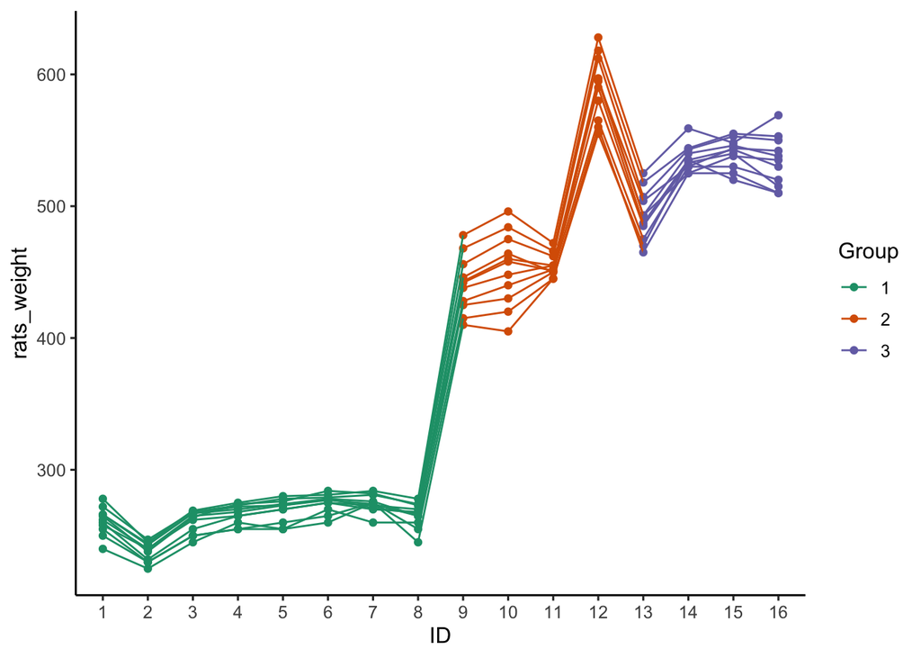

```r
library(ggplot2)
ggplot(RATSL, aes(x = ID, y = rats_weight, color = Group, group = Time)) +
  geom_point() +
  geom_line() +
  scale_color_brewer(palette = 'Dark2') +
  theme_classic(base_size = 12)
```

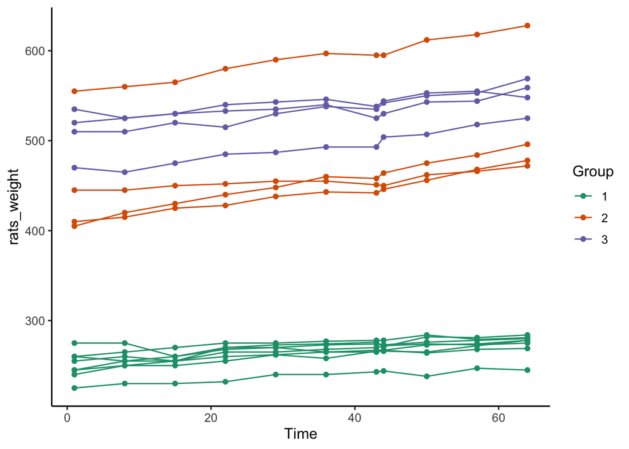

```r
ggplot(RATSL, aes(x = Time, y = rats_weight, color = Group, group = ID)) +
  geom_point() +
  geom_line() +
  scale_color_brewer(palette = 'Dark2') +
  theme_classic(base_size = 12)
```

In the above plots, we can see the growth pattern from the first measurement to the last measurement is quite similar. However, we need to do further analysis to see whether the growth profiles of the three groups differ.

So we would like to check the growth pattern for each group by ANOVA analysis. In the begining, we plot a boxplot to see the rough data distribution in the dataset for each group.

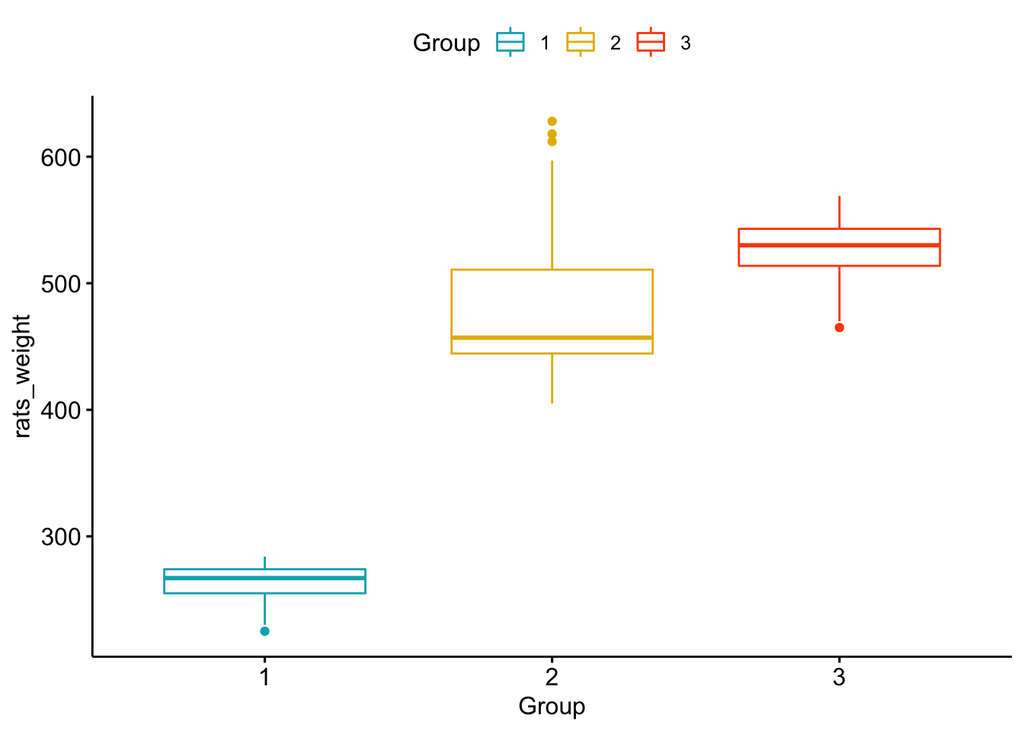

```r
# Box plots
# ++++++++++++++++++++
# Plot weight by group and color by group
library(ggpubr)
ggboxplot(RATSL, x = "Group", y = "rats_weight",
          color = "Group", palette = c("#00AFBB", "#E7B800", "#FC4E07"),
          order = c("1", "2", "3"),
          ylab = "rats_weight", xlab = "Group")
```

And then, we would like to seperate each group’s data from the original RATSL dataset.

```r
library(tidyverse)
RATSL_1 <- RATSL %>% filter(Group==1)
RATSL_2 <- RATSL %>% filter(Group==2)
RATSL_3 <- RATSL %>% filter(Group==3)
```

Now, we can standardized the rats_weight in RATSL dataset and conduct ANOVA anaysis to see the relationship between rat’s weight and the time. We assume that H0 is when rats’ weight is not related to the time and H1 is when rats’ weight is related to the time.

## 3. Analyze dataset

```r
library(standardize)
# Standardize rats_weight of RATSL_1 dataset
RATSL_1$rats_weight <- scale(RATSL_1$rats_weight)
# Standardize rats_weight of RATSL_2 dataset
RATSL_2$rats_weight <- scale(RATSL_2$rats_weight)
# Standardize rats_weight of RATSL_3 dataset
RATSL_3$rats_weight <- scale(RATSL_3$rats_weight)

# Compute the analysis of variance
RATSL_1_aov <- aov(rats_weight ~ Time, data = RATSL_1)
RATSL_2_aov <- aov(rats_weight ~ Time, data = RATSL_2)
RATSL_3_aov <- aov(rats_weight ~ Time, data = RATSL_3)

# Summary of the analysis
summary(RATSL_1_aov)
```

```
##             Df Sum Sq Mean Sq F value   Pr(>F)
## Time         1  22.99  22.990   30.89 3.01e-07 ***
## Residuals   86  64.01   0.744
## ---
## Signif. codes:  0 '***' 0.001 '**' 0.01 '*' 0.05 '.' 0.1 ' ' 1
```

```r
summary(RATSL_2_aov)
```

```
##             Df Sum Sq Mean Sq F value Pr(>F)
## Time         1   3.63   3.633   3.876 0.0556 .
## Residuals   42  39.37   0.937
## ---
## Signif. codes:  0 '***' 0.001 '**' 0.01 '*' 0.05 '.' 0.1 ' ' 1
```

```r
summary(RATSL_3_aov)
```

```
##             Df Sum Sq Mean Sq F value   Pr(>F)
## Time         1  12.08  12.076    16.4 0.000216 ***
## Residuals   42  30.92   0.736
## ---
## Signif. codes:  0 '***' 0.001 '**' 0.01 '*' 0.05 '.' 0.1 ' ' 1
```

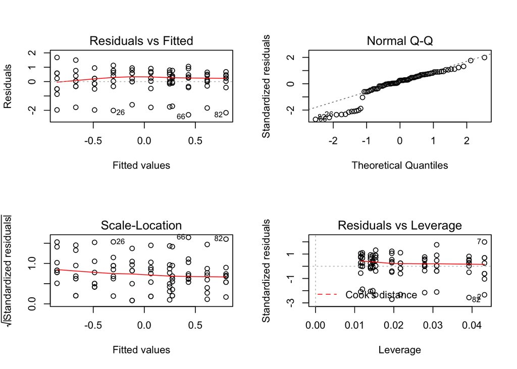

```r
par(mfrow=c(2,2))
plot(RATSL_1_aov)
```

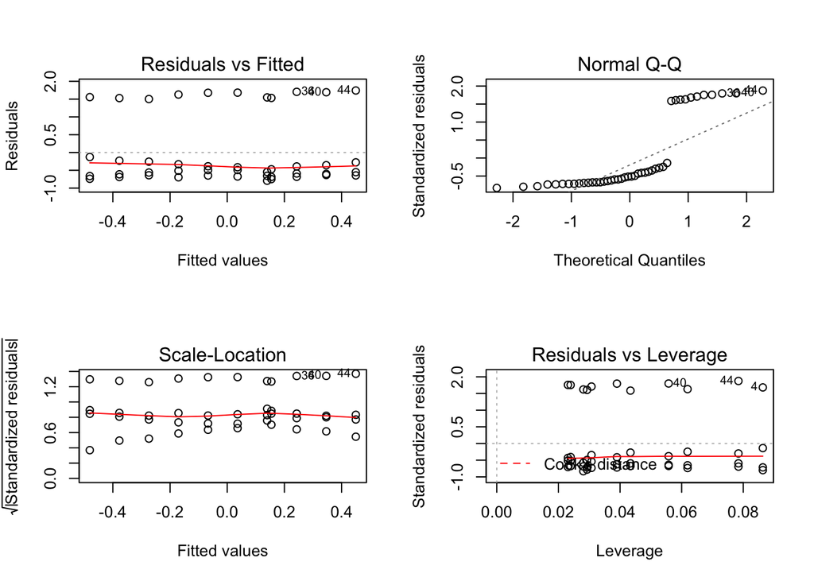

```r
plot(RATSL_2_aov)
```

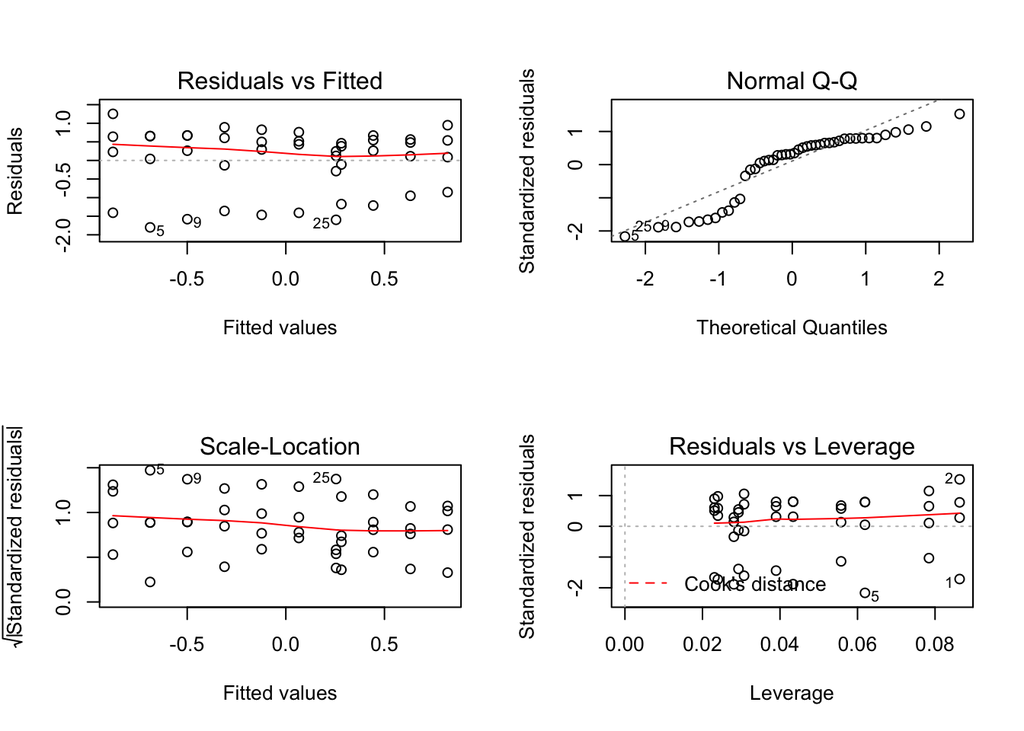

```r
plot(RATSL_3_aov)
```

#### (0-3 points) Interpretations

In addtion, in ANOVA analysis Normal Q-Q plot of group 2, the dots are not well distributed on the line, which suggests that it is a bimodal distribution for the original data distribution.

## Data Preparing: “BPRS” dataset

BPRS (Brief Psychiatric Rating Scale) dataset is measured before treatment began (week 0) and then at weekly intervals for eight weeks. The BPRS assesses the level of 18 symptom constructs such as hostility, suspiciousness, hallucinations and grandiosity; each of these is rated from one (not present) to seven (extremely severe). **The scale is used to evaluate patients suspected of having schizophrenia**.

## 1. Load dataset2

```r
BPRS <- read.table("https://raw.githubusercontent.com/KimmoVehkalahti/MABS/master/Examples/data/BPRS.txt", header = T)
# variables' names
names(BPRS)
```

```
##  [1] "treatment" "subject"   "week0"     "week1"     "week2"     "week3"
##  [7] "week4"     "week5"     "week6"     "week7"     "week8"
```

```r
# RATS dataset structure
str(BPRS)
```

```
## 'data.frame':    40 obs. of  11 variables:
##  $ treatment: int  1 1 1 1 1 1 1 1 1 1 ...
##  $ subject  : int  1 2 3 4 5 6 7 8 9 10 ...
##  $ week0    : int  42 58 54 55 72 48 71 30 41 57 ...
##  $ week1    : int  36 68 55 77 75 43 61 36 43 51 ...
##  $ week2    : int  36 61 41 49 72 41 47 38 39 51 ...
##  $ week3    : int  43 55 38 54 65 38 30 38 35 55 ...
##  $ week4    : int  41 43 43 56 50 36 27 31 28 53 ...
##  $ week5    : int  40 34 28 50 39 29 40 26 22 43 ...
##  $ week6    : int  38 28 29 47 32 33 30 26 20 43 ...
##  $ week7    : int  47 28 25 42 38 27 31 25 23 39 ...
##  $ week8    : int  51 28 24 46 32 25 31 24 21 32 ...
```

```r
# RATS dataset summary
summary(BPRS)
```

```
##    treatment      subject          week0           week1           week2
##  Min.   :1.0   Min.   : 1.00   Min.   :24.00   Min.   :23.00   Min.   :26.0
##  1st Qu.:1.0   1st Qu.: 5.75   1st Qu.:38.00   1st Qu.:35.00   1st Qu.:32.0
##  Median :1.5   Median :10.50   Median :46.00   Median :41.00   Median :38.0
##  Mean   :1.5   Mean   :10.50   Mean   :48.00   Mean   :46.33   Mean   :41.7
##  3rd Qu.:2.0   3rd Qu.:15.25   3rd Qu.:58.25   3rd Qu.:54.25   3rd Qu.:49.0
##  Max.   :2.0   Max.   :20.00   Max.   :78.00   Max.   :95.00   Max.   :75.0
##      week3           week4           week5           week6           week7
##  Min.   :24.00   Min.   :20.00   Min.   :20.00   Min.   :19.00   Min.   :18.0
##  1st Qu.:29.75   1st Qu.:28.00   1st Qu.:26.00   1st Qu.:22.75   1st Qu.:23.0
##  Median :36.50   Median :34.50   Median :30.50   Median :28.50   Median :30.0
##  Mean   :39.15   Mean   :36.35   Mean   :32.55   Mean   :31.23   Mean   :32.2
##  3rd Qu.:44.50   3rd Qu.:43.00   3rd Qu.:38.00   3rd Qu.:37.00   3rd Qu.:38.0
##  Max.   :76.00   Max.   :66.00   Max.   :64.00   Max.   :64.00   Max.   :62.0
##      week8
##  Min.   :20.00
##  1st Qu.:22.75
##  Median :28.00
##  Mean   :31.43
##  3rd Qu.:35.25
##  Max.   :75.00
```

Since the attribite of treatment and subject are categorical variables, we can change the type of the dataset from integer to factor by factor() function!

```r
library(dplyr) # Access the packages dplyr and tidyr
library(tidyr)
BPRS$treatment <- factor(BPRS$treatment) # Factor treatment & subject
BPRS$subject <- factor(BPRS$subject)
str(BPRS)
```

```
## 'data.frame':    40 obs. of  11 variables:
##  $ treatment: Factor w/ 2 levels "1","2": 1 1 1 1 1 1 1 1 1 1 ...
##  $ subject  : Factor w/ 20 levels "1","2","3","4",..: 1 2 3 4 5 6 7 8 9 10 ...
##  $ week0    : int  42 58 54 55 72 48 71 30 41 57 ...
##  $ week1    : int  36 68 55 77 75 43 61 36 43 51 ...
##  $ week2    : int  36 61 41 49 72 41 47 38 39 51 ...
##  $ week3    : int  43 55 38 54 65 38 30 38 35 55 ...
##  $ week4    : int  41 43 43 56 50 36 27 31 28 53 ...
##  $ week5    : int  40 34 28 50 39 29 40 26 22 43 ...
##  $ week6    : int  38 28 29 47 32 33 30 26 20 43 ...
##  $ week7    : int  47 28 25 42 38 27 31 25 23 39 ...
##  $ week8    : int  51 28 24 46 32 25 31 24 21 32 ...
```

In order to visulaize the data, we would like to convert the original wide-form to long-form first.

```r
BPRSL <- BPRS %>% gather(key = week, value = scale, -treatment, -subject) # Convert to long-form
BPRSL <-  BPRSL %>% mutate(Week = as.integer(substr(week, 5, 5))) # Extract the week number, from the 5th letter to the 5 th letter
glimpse(BPRSL)
```

```
## Observations: 360
## Variables: 5
## $ treatment <fct> 1, 1, 1, 1, 1, 1, 1, 1, 1, 1, 1, 1, 1, 1, 1, 1, 1, 1, 1, 1,…
## $ subject   <fct> 1, 2, 3, 4, 5, 6, 7, 8, 9, 10, 11, 12, 13, 14, 15, 16, 17, …
## $ week      <chr> "week0", "week0", "week0", "week0", "week0", "week0", "week…
## $ scale     <int> 42, 58, 54, 55, 72, 48, 71, 30, 41, 57, 30, 55, 36, 38, 66,…
## $ Week      <int> 0, 0, 0, 0, 0, 0, 0, 0, 0, 0, 0, 0, 0, 0, 0, 0, 0, 0, 0, 0,…
```

Since the “Week” variable also belongs to categorical data, we can use factor() function to factorize it!

```r
BPRSL$Week <- factor(BPRSL$Week)
glimpse(BPRSL)
```

```
## Observations: 360
## Variables: 5
## $ treatment <fct> 1, 1, 1, 1, 1, 1, 1, 1, 1, 1, 1, 1, 1, 1, 1, 1, 1, 1, 1, 1,…
## $ subject   <fct> 1, 2, 3, 4, 5, 6, 7, 8, 9, 10, 11, 12, 13, 14, 15, 16, 17, …
## $ week      <chr> "week0", "week0", "week0", "week0", "week0", "week0", "week…
## $ scale     <int> 42, 58, 54, 55, 72, 48, 71, 30, 41, 57, 30, 55, 36, 38, 66,…
## $ Week      <fct> 0, 0, 0, 0, 0, 0, 0, 0, 0, 0, 0, 0, 0, 0, 0, 0, 0, 0, 0, 0,…
```

Let’s visualize the BPRSL dataset by ox chart.

## 2. Visualize dataset

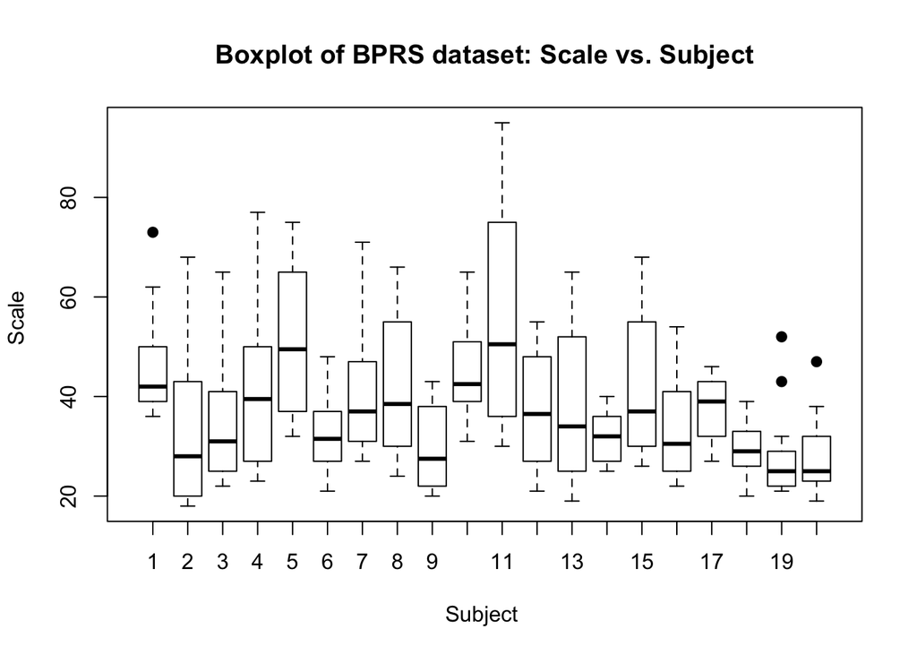

```r
attach(BPRSL)
plot(subject, scale, main="Boxplot of BPRS dataset: Scale vs. Subject",
   xlab="Subject ", ylab="Scale ", pch=19)
```

In the above boxplot, we can see the scale result of 8-week-treatment for each subject. We can clearly see the 1st, 19th and 20th subjects has some abnormally high scale during the observation which may suggest that the patients’ condition is not quite stable, so they perhaps need further therapy or observation.

```r
attach(BPRSL)
```

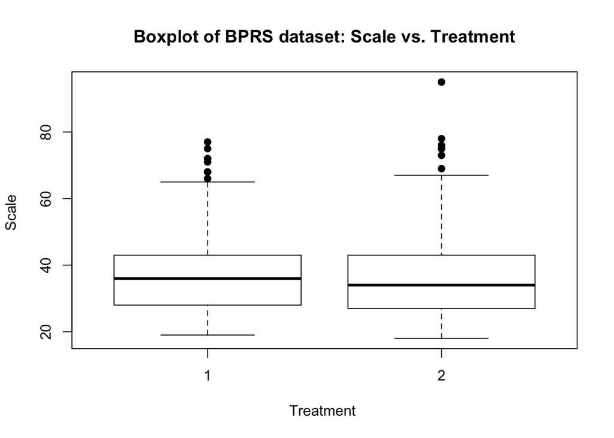

```r
plot(treatment, scale, main="Boxplot of BPRS dataset: Scale vs. Treatment",
   xlab="Treatment ", ylab="Scale ", pch=19)
```

In the above boxchart, the two treatment implemented in this observation seems has not so much differences. Both means are around but less than 40 and the treatment no.2 is a bit less than treatment no.1.

```r
attach(BPRSL)
```

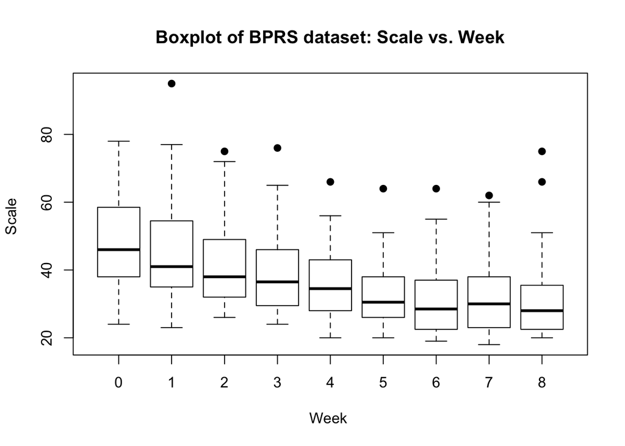

```r
plot(Week, scale, main="Boxplot of BPRS dataset: Scale vs. Week",
   xlab="Week ", ylab="Scale ", pch=19)
```

In the above boxchart, it is quite clear to see the patients’ average scales are decreasing along the time (week).

## 3. Analyze dataset

According to the boxplots above, we know that the average patients’ condition are getting better through the series of treatments.